# Replicating Slater et al. (2025) for Catalunya: first results

We fitted model 1 of Slater et al. (2025) to daily COVID-19 cases in the 374 basic health areas (ABS) of Catalunya, 22 March 2020 to 1 May 2021. The model keeps their four components (endemic, autoregressive, neighbourhood and mobility), their area-specific coefficients, priors, Poisson likelihood and sampler settings. Three changes adapt it to daily counts: cases lagged by one week (equal weights on days 7 to 13), trips summed over the 7 days up to each lagged case day and the 7 days before, and a day-of-week reporting factor.

```r
library(ggplot2)
library(sf)
source("helpers.R")
key = paste(params$areas, params$from, params$to, sep = "_")
d = readRDS(out(paste0("daily_", key, "_inputs.rds")))
fit = readRDS(out(paste0("daily_", key, "_", params$lag, ".rds")))
loo_result = readRDS(out(paste0("daily_", key, "_", params$lag, "_loo.rds")))
draws = rstan::extract(fit)
weekday = as.integer(format(d$dates, "%u"))
day_number = as.numeric(d$dates - DAY1) + 1
weekday_draw = draws$weekday_effect[, weekday]   # draw x day
pct = \(x) paste0(round(100 * x), "%")
theme_set(theme_minimal(base_size = 12) + theme(panel.grid.minor = element_blank(), legend.position = "top"))
COMPONENT_COLOURS = c(Aggregate = "black", Autoregressive = "blue", Endemic = "orange", Mobility = "red", Neighbourhood = "green")
bands = \(x) data.frame(t(apply(x, 2, quantile, c(0.025, 0.5, 0.975)))) |> setNames(c("lo", "mid", "hi"))
date_axis = scale_x_date(limits = range(d$dates), expand = c(0, 0), date_breaks = "1 month",
    labels = \(x) ifelse(format(x, "%m") == "01" | seq_along(x) == which(!is.na(x))[1], format(x, "%b\n%Y"), format(x, "%b")))
```

## Fit

```r
s = rstan::summary(fit, pars = c("endemic", "autoregressive", "neighbour", "mobility"))$summary
pareto_k = loo::pareto_k_values(loo_result)
data.frame(check = c("Divergent transitions", "Largest R-hat", "Parameters with R-hat above 1.01",
        "Smallest effective sample size", "PSIS-LOO elpd (SE)", "ABS-days with Pareto k above 0.7"),
    value = c(rstan::get_num_divergent(fit), sprintf("%.3f", max(s[, "Rhat"])),
        sprintf("%d of %d", sum(s[, "Rhat"] > 1.01), nrow(s)), round(min(s[, "n_eff"])),
        sprintf("%.0f (%.0f)", loo_result$estimates["elpd_loo", "Estimate"], loo_result$estimates["elpd_loo", "SE"]),
        sprintf("%d of %d", sum(pareto_k > 0.7), length(pareto_k)))) |>
    knitr::kable(col.names = NULL)
```

| Divergent transitions | 0 |
| --- | --- |
| Largest R-hat | 1.020 |
| Parameters with R-hat above 1.01 | 8 of 1870 |
| Smallest effective sample size | 199 |
| PSIS-LOO elpd (SE) | -380164 (1573) |
| ABS-days with Pareto k above 0.7 | 45 of 151844 |

The sampler shows no divergences. A few parameters sit just above the R-hat threshold of 1.01 that Slater et al. use.

## Mobility is the largest component

Expected cases by component, summed over the ABS, posterior medians. Periods follow the case curve.

```r
daily = sapply(c(Endemic = "endemic_day", Autoregressive = "autoregressive_day", Neighbourhood = "neighbour_day",
    Mobility = "mobility_day"), \(v) apply(draws[[v]] * weekday_draw, 2, median))
periods = cut(d$dates, as.Date(c("2020-03-22", "2020-05-11", "2020-07-01", "2020-10-01", "2020-12-15", "2021-03-01", "2021-05-02")),
    labels = c("Lockdown, 22 Mar to 10 May 2020", "Reopening, May to June", "Summer, July to September",
        "Second wave, October to mid-December", "Third wave, mid-December to February", "Spring 2021"), right = FALSE)
by_period = rbind(rowsum(daily, periods), `Whole period` = colSums(daily))
overall = by_period["Whole period", ] / sum(by_period["Whole period", ])
share_table = apply(by_period / rowSums(by_period), 2, pct)
rownames(share_table) = rownames(by_period)
knitr::kable(share_table)
```

|  | Endemic | Autoregressive | Neighbourhood | Mobility |
| --- | --- | --- | --- | --- |
| Lockdown, 22 Mar to 10 May 2020 | 16% | 16% | 13% | 55% |
| Reopening, May to June | 41% | 12% | 9% | 38% |
| Summer, July to September | 15% | 15% | 11% | 59% |
| Second wave, October to mid-December | 6% | 16% | 12% | 66% |
| Third wave, mid-December to February | 6% | 15% | 13% | 65% |
| Spring 2021 | 10% | 14% | 11% | 64% |
| Whole period | 10% | 15% | 12% | 63% |

Mobility accounts for 63% of the expected cases over the whole period, and is the largest component in every period except the reopening. Then cases were very low and the constant endemic rate made up a large share of a small total. The autoregressive and neighbourhood components stay between 9% and 16% throughout. Slater et al. report the same ordering for Castilla–León.

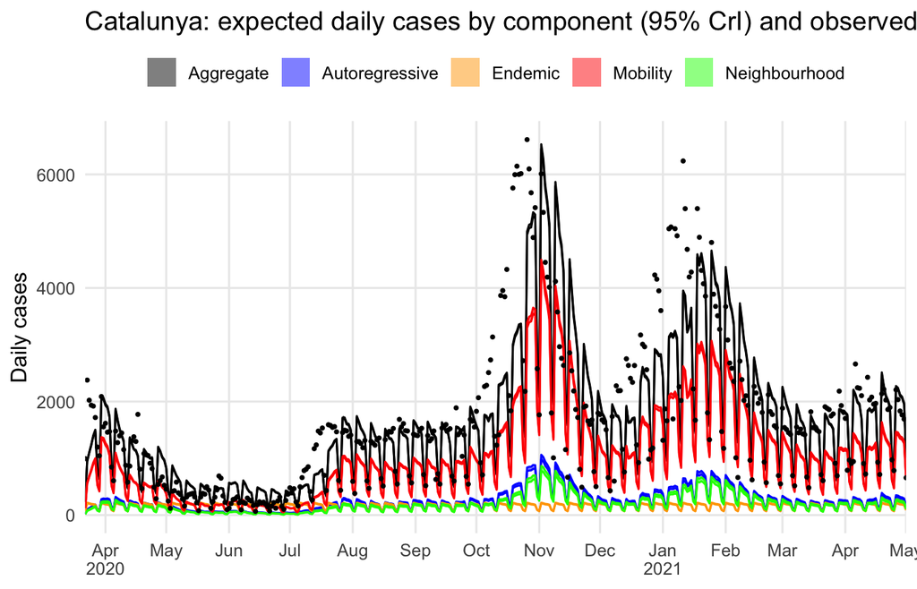

```r
parts = lapply(list(Autoregressive = "autoregressive_day", Endemic = "endemic_day", Mobility = "mobility_day",
    Neighbourhood = "neighbour_day"), \(v) draws[[v]] * weekday_draw)
parts$Aggregate = Reduce(`+`, parts)
b = do.call(rbind, lapply(names(parts), \(k) cbind(bands(parts[[k]]), date = d$dates, component = k)))
ggplot(b, aes(date)) +
    geom_ribbon(aes(ymin = lo, ymax = hi, fill = component, colour = component), alpha = 0.5) +
    geom_point(data = data.frame(date = d$dates, cases = colSums(d$cases)), aes(y = cases), size = 0.6) +
    scale_fill_manual(values = COMPONENT_COLOURS) + scale_colour_manual(values = COMPONENT_COLOURS) +
    guides(colour = "none") + date_axis +
    labs(x = NULL, y = "Daily cases", fill = NULL, title = "Catalunya: expected daily cases by component (95% CrI) and observed cases")
```

## Components by ABS

Each component’s share of the expected cases in each ABS, over the whole period.

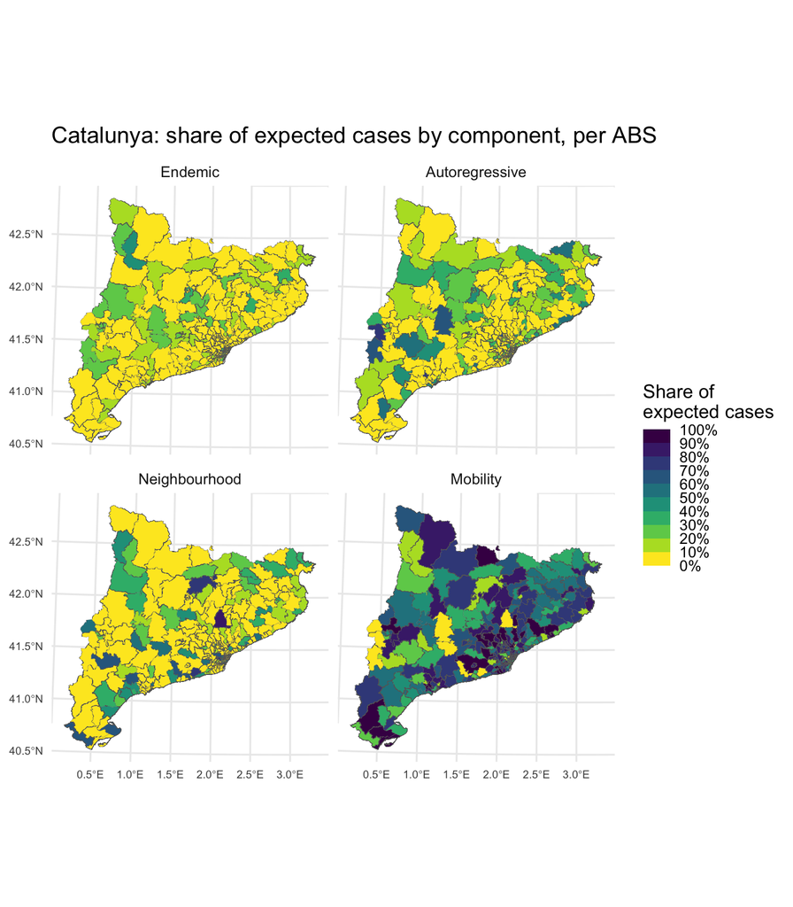

```r
weighted = \(x) Reduce(`+`, lapply(seq_along(x), \(k) t(x[[k]] %*% t(weekday_draw)) * draws$lag_weight[, k]))   # draw x ABS
by_pop = \(coef) sweep(coef, 2, d$pop, `*`)
area_parts = list(Endemic = by_pop(draws$endemic) * rowSums(weekday_draw),
    Autoregressive = draws$autoregressive * weighted(d$lagged_cases),
    Neighbourhood = by_pop(draws$neighbour) * weighted(d$neighbour_pressure),
    Mobility = draws$mobility[, 1, ] * weighted(d$mobility_pressure1) + draws$mobility[, 2, ] * weighted(d$mobility_pressure2))
area_total = Reduce(`+`, area_parts)
abs_geometry = st_read(spain("outputs/catalunya/geometry/cat_abs.gpkg"), quiet = TRUE) |>
    dplyr::filter(id %in% d$ids) |> dplyr::arrange(id)
shares = do.call(rbind, lapply(names(area_parts), \(k) cbind(abs_geometry,
    component = factor(k, names(area_parts)), share = apply(area_parts[[k]] / area_total, 2, median))))
mobility_share = shares$share[shares$component == "Mobility"]
ggplot(shares) +
    geom_sf(aes(fill = share), colour = "grey40", linewidth = 0.05) +
    scale_fill_viridis_b(breaks = seq(0, 1, 0.1), limits = c(0, 1), labels = scales::percent, direction = -1) +
    facet_wrap(~component) +
    coord_sf(datum = 4326) +
    labs(title = "Catalunya: share of expected cases by component, per ABS", fill = "Share of\nexpected cases") +
    theme(legend.position = "right", axis.text = element_text(size = 7))
```

Mobility is the largest component in 260 of 374 ABS (median share 69%), including most of the Barcelona metropolitan area and the coast. A scattered set of ABS, mostly rural, has larger autoregressive or neighbourhood shares. The mobility panel is, by definition, the proportion of cases attributable to movement (PCAtM) of Slater et al. for each ABS: a model-based share of expected cases, not a count of cases from travel.

The same shares on an interactive map: choose a component in the box at the top right, or “None” for the ABS boundaries alone. Hover over an ABS for its name and value; click for all four shares.

```r
library(leaflet)
share_table_abs = sapply(area_parts, \(x) apply(x / area_total, 2, median))   # ABS x component
abs_names = read.csv(spain("outputs/catalunya/tables/cat_abs_areas.csv"), colClasses = c(id = "character"))
abs_label = abs_names$name[match(d$ids, abs_names$id)]
interactive = abs_geometry |> st_simplify(dTolerance = 50) |> st_transform(4326)
palette = colorBin("viridis", domain = c(0, 1), bins = seq(0, 1, 0.1), reverse = TRUE)
popup = sprintf("<b>%s</b><br>%s", abs_label, apply(share_table_abs, 1, \(x) paste(colnames(share_table_abs), pct(x), sep = ": ", collapse = "<br>")))
m = leaflet(interactive) |> addProviderTiles(providers$Esri.WorldGrayCanvas)   # plain light background, no key needed
for (k in colnames(share_table_abs))
    m = addPolygons(m, fillColor = palette(share_table_abs[, k]), fillOpacity = 0.7, color = "grey40", weight = 0.3,
        group = k, label = sprintf("%s: %s", abs_label, pct(share_table_abs[, k])), popup = popup,
        highlightOptions = highlightOptions(weight = 2, color = "black", bringToFront = TRUE))
m |>
    addPolygons(fill = FALSE, color = "grey40", weight = 0.5, group = "None (boundaries only)") |>
    addLegend(pal = palette, values = c(0, 1), opacity = 0.7, title = "Share of<br>expected cases", position = "bottomright",
        labFormat = labelFormat(suffix = "%", transform = \(x) 100 * x)) |>
    addLayersControl(baseGroups = c(colnames(share_table_abs), "None (boundaries only)"),
        options = layersControlOptions(collapsed = FALSE))
```

[interactive chart not shown]

## Trips per new infection

```r
trips_per_infection = quantile(1 / draws$infections_per_trip, c(0.025, 0.5, 0.975))
```

About 50 infected trips are associated with one new infection (95% CrI 49 to 50). Slater et al. report about 70 for Castilla–León and about 140 for Madrid outside the city.

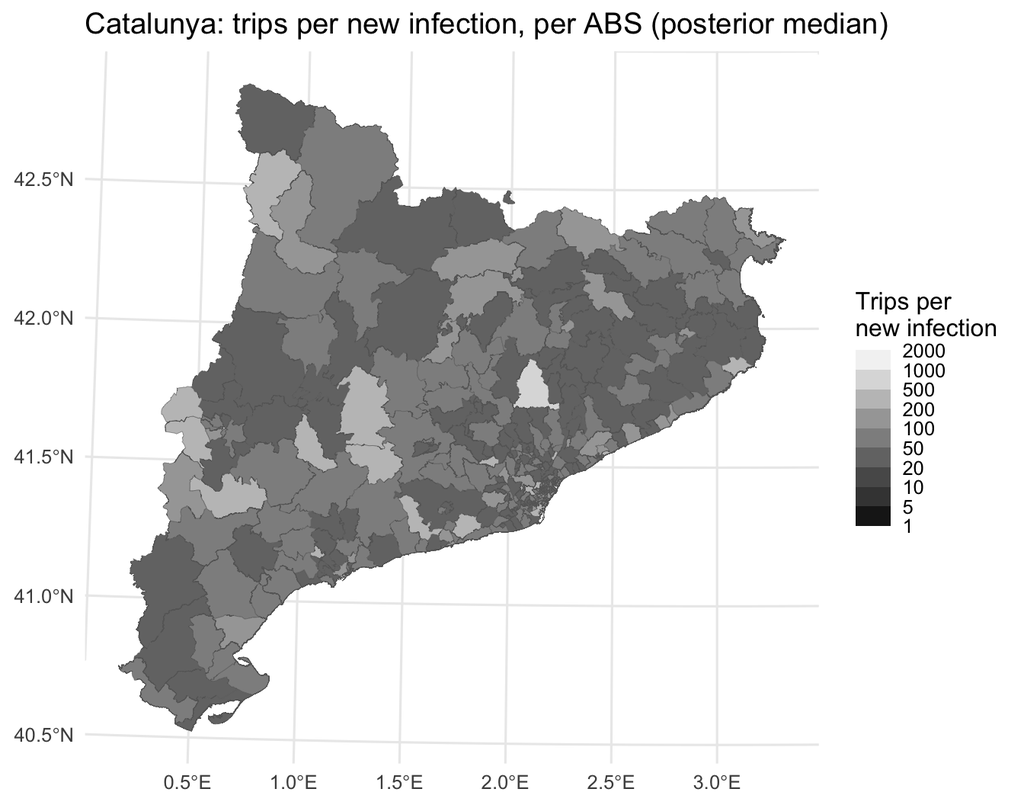

```r
breaks = c(1, 5, 10, 20, 50, 100, 200, 500, 1000, 2000)
abs_geometry$trips = bands(1 / draws$infections_per_trip_area)$mid
ggplot(abs_geometry) +
    geom_sf(aes(fill = trips), colour = "grey40", linewidth = 0.1) +
    scale_fill_stepsn(colours = gray(seq(0, 1, length.out = length(breaks) - 1)), breaks = breaks, limits = range(breaks),
        trans = "log10", oob = scales::squish) +
    coord_sf(datum = 4326) +
    labs(title = "Catalunya: trips per new infection, per ABS (posterior median)", fill = "Trips per\nnew infection") +
    theme(legend.position = "right")
```

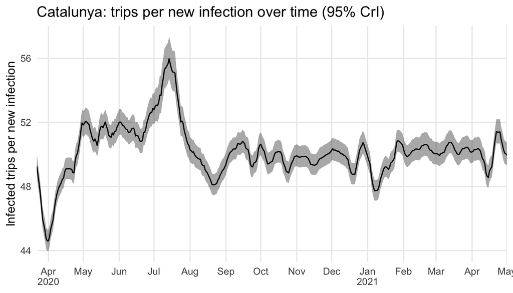

```r
cbind(bands(1 / draws$infections_per_trip_day), date = d$dates) |>
    ggplot(aes(date)) +
    geom_ribbon(aes(ymin = lo, ymax = hi), alpha = 0.4) +
    geom_line(aes(y = mid)) +
    date_axis +
    labs(x = NULL, y = "Infected trips per new infection", title = "Catalunya: trips per new infection over time (95% CrI)")
```

The number stays between about 44 and 56 over the whole period. This stability follows from the model: each ABS has one coefficient for the whole period, so only the mix of trips and infections across ABS changes.

## Reproduction number

Dominant eigenvalue of the next-generation matrix each week (their equation 6), from 50 posterior draws, scaled by the mean weekday factor.

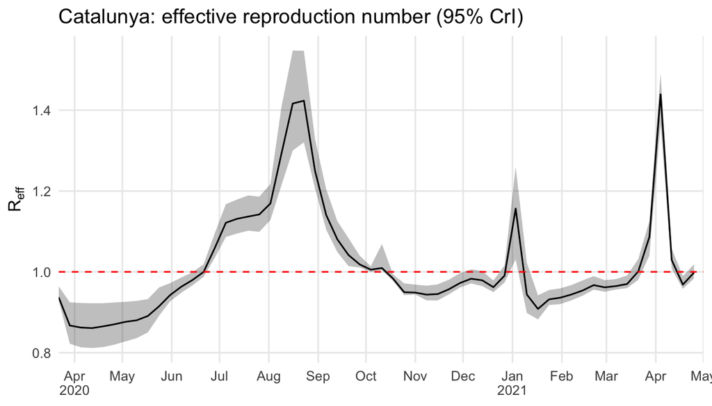

```r
reff_file = out(paste0("reff_", key, "_", params$lag, ".rds"))
at = seq(1, length(d$dates), by = 7)
if (file.exists(reff_file)) basic_R = readRDS(reff_file) else {
    window = trip_windows(d$ids, day_number[at])
    spatial_weights = neighbour_weights(d$ids)
    basic_R = matrix(nrow = 50, ncol = length(at))
    for (sample in 1:50) for (t in seq_along(at)) {
        Phi = (window(day_number[at[t]], 6, 0) %*% diag(draws$mobility[sample, 1, ]) +
            window(day_number[at[t]], 13, 7) %*% diag(draws$mobility[sample, 2, ]) +
            spatial_weights %*% diag(d$pop * draws$neighbour[sample, ])) / d$pop + diag(draws$autoregressive[sample, ])
        basic_R[sample, t] = max(Mod(eigen(Phi, only.values = TRUE)$values)) * mean(draws$weekday_effect[sample, ])
    }
    saveRDS(basic_R, reff_file)
}
r_eff = cbind(bands(basic_R), date = d$dates[at])
ggplot(r_eff, aes(date)) +
    geom_ribbon(aes(ymin = lo, ymax = hi), alpha = 0.3) +
    geom_line(aes(y = mid)) +
    geom_hline(yintercept = 1, linetype = 2, colour = "red") +
    date_axis +
    labs(x = NULL, y = expression(R[eff]), title = "Catalunya: effective reproduction number (95% CrI)")
```

R_eff is below 1 during the lockdown, crosses 1 in June as trips recover, and peaks at about 1.4 in August. It returns to about 1 by October and stays just below 1 through the winter. Two short spikes, at New Year and at Easter 2021, coincide with holidays and have no counterpart in the cases; they need checking before use.

## The fit trails the waves

Correlation between observed weekly cases and expected weekly cases k weeks later.

```r
observed = tapply(colSums(d$cases), ceiling(seq_along(d$dates) / 7), sum)
expected = tapply(rowSums(daily), ceiling(seq_along(d$dates) / 7), sum)
inner = 4:(length(observed) - 4)
lag_corr = sapply(-2:2, \(k) cor(observed[inner], expected[inner + k]))
knitr::kable(t(round(lag_corr, 2)), col.names = paste("k =", -2:2))
```

| k = -2 | k = -1 | k = 0 | k = 1 | k = 2 |
| --- | --- | --- | --- | --- |
| 0.48 | 0.68 | 0.87 | 0.99 | 0.96 |

Expected cases match observed cases best one week later (0.99, against 0.87 in the same week). The model underestimates the October rise and overestimates the decline. With a one-week case lag and constant coefficients, it mostly carries the previous week forward. Over the whole period the totals agree (observed / expected = 0.997).

## Lag between trips and case growth

Crude R_t (cases of the last 7 days over the 7 days before) against trips of the 7 days ending h days earlier, as their exploratory analysis.

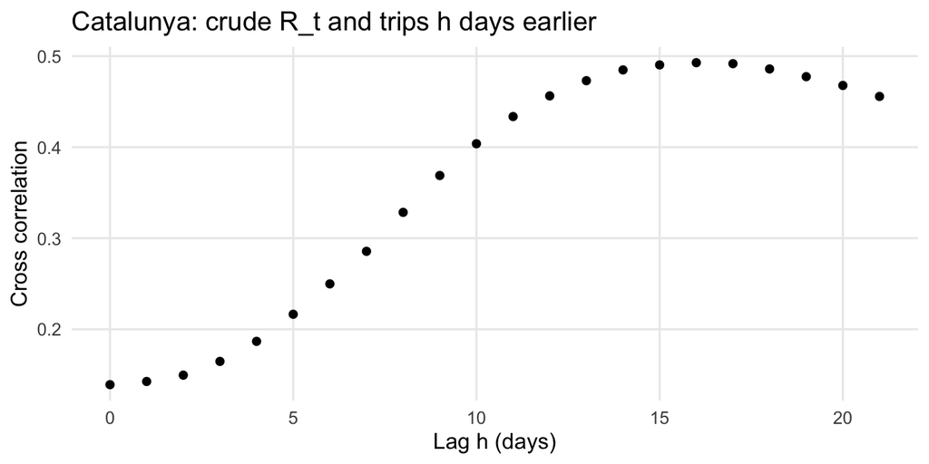

```r
total_cases = read_cases(d$ids)$cases |> colSums()
seven = \(x, t) vapply(t, \(u) sum(x[u - 0:6]), numeric(1))
crude_r = seven(total_cases, day_number) / seven(total_cases, day_number - 7)
window = trip_windows(d$ids, (min(day_number) - 21):max(day_number))
trips7 = \(lag) vapply(day_number - lag, \(u) sum(window(u, 6, 0)), numeric(1))
ccf = data.frame(lag = 0:21, correlation = vapply(0:21, \(h) cor(crude_r, trips7(h)), numeric(1)))
ggplot(ccf, aes(lag, correlation)) +
    geom_point() +
    labs(x = "Lag h (days)", y = "Cross correlation", title = "Catalunya: crude R_t and trips h days earlier")
```

The correlation is strongest for trips made about 16 days earlier (0.49), in line with their pairing of last week’s cases with trips one and two weeks before.

## Comparison with Slater et al. (2025)

Their values are for model 1 (no serial interval), from their Table 1 and Figures 3, 5 and 6.

```r
reff_above = r_eff$date[r_eff$mid > 1]
data.frame(
    Item = c("Areas and resolution", "Period modelled", "Likelihood", "Largest component",
        "Mobility share of expected cases (their PCAtM)", "Trips per new infection", "Trips per infection over time",
        "R_eff above 1", "Lag of trips most correlated with growth", "Convergence", "Pareto k above 0.7"),
    `Slater et al., Castilla-León` = c("245 health zones, weekly", "Weeks 4 to 53 (22 March 2020 to early March 2021)", "Poisson",
        "Mobility, then autoregressive and spatial; endemic negligible", "45% (44 to 46)", "About 70",
        "Roughly constant, 64 to 76", "About July to October 2020, peak about 1.1", "1 to 2 weeks",
        "R-hat below 1.01", "About 3% of observations"),
    `Slater et al., Madrid` = c("179 municipalities and districts, weekly", "22 March 2020 to May 2021", "Poisson (testing-adjusted)",
        "Autoregressive, then mobility", "17% (16 to 18)", "About 140 (outside Madrid City)",
        "Roughly constant, 120 to 175", "Not shown", "Not reported", "R-hat below 1.01", "About 1.5%"),
    `This replication, Catalunya` = c("374 ABS, daily", "22 March 2020 to 1 May 2021", "Poisson with day-of-week factor",
        "Mobility, then autoregressive, neighbourhood and endemic",
        pct(overall["Mobility"]), sprintf("%.0f (%.0f to %.0f)", trips_per_infection[2], trips_per_infection[1], trips_per_infection[3]),
        do.call(sprintf, c("Roughly constant, %.0f to %.0f", as.list(range(bands(1 / draws$infections_per_trip_day)$mid)))),
        sprintf("%s to %s 2020, peak about %.1f; short holiday spikes", format(min(reff_above), "%B"), format(max(reff_above[reff_above < as.Date("2020-12-01")]), "%B"), max(r_eff$mid)),
        sprintf("About %d days", ccf$lag[which.max(ccf$correlation)]),
        sprintf("R-hat at most %.2f; %d of %d above 1.01", max(s[, "Rhat"]), sum(s[, "Rhat"] > 1.01), nrow(s)),
        sprintf("%.2f%% of ABS-days", 100 * mean(pareto_k > 0.7))),
    check.names = FALSE) |>
    knitr::kable()
```

| Item | Slater et al., Castilla-León | Slater et al., Madrid | This replication, Catalunya |
| --- | --- | --- | --- |
| Areas and resolution | 245 health zones, weekly | 179 municipalities and districts, weekly | 374 ABS, daily |
| Period modelled | Weeks 4 to 53 (22 March 2020 to early March 2021) | 22 March 2020 to May 2021 | 22 March 2020 to 1 May 2021 |
| Likelihood | Poisson | Poisson (testing-adjusted) | Poisson with day-of-week factor |
| Largest component | Mobility, then autoregressive and spatial; endemic negligible | Autoregressive, then mobility | Mobility, then autoregressive, neighbourhood and endemic |
| Mobility share of expected cases (their PCAtM) | 45% (44 to 46) | 17% (16 to 18) | 63% |
| Trips per new infection | About 70 | About 140 (outside Madrid City) | 50 (49 to 50) |
| Trips per infection over time | Roughly constant, 64 to 76 | Roughly constant, 120 to 175 | Roughly constant, 45 to 56 |
| R_eff above 1 | About July to October 2020, peak about 1.1 | Not shown | June to October 2020, peak about 1.4; short holiday spikes |
| Lag of trips most correlated with growth | 1 to 2 weeks | Not reported | About 16 days |
| Convergence | R-hat below 1.01 | R-hat below 1.01 | R-hat at most 1.02; 8 of 1870 above 1.01 |
| Pareto k above 0.7 | About 3% of observations | About 1.5% | 0.03% of ABS-days |

The replication matches their Castilla–León result in ordering and in the near-constant trips per infection. Catalunya needs fewer trips per infection, and mobility makes up a larger share of the expected cases. Our case counts include antigen and other positive tests and are daily, so the levels are not directly comparable.